# Leíró statisztikai eszközök R-ben

## 1. Dataframe beolvasása speciális csv formátumból

A Moodle-n található titanic_utasok.csv fájl egy olyan adattábla, ami a Titanic 1043 utasáról 8 változó (oszlop) adatát tárolja:

- **Osztaly**: Az utas kabinjának osztálya (I., II. vagy III. osztály)
- **Tulelt_e**: Túlélte-e utasunk a jégheggyel való találkát? (igen/nem)
- **Nev**: Utasunk neve
- **Nem**: Utasunk neme (férfi/nő)
- **Kor**: Utasunk életkora az utazáskor években
- **Viteldij**: Utasunk által az útért fizetett díj angol fontban
- **BeszallasHelye**: Utasunk melyik állomáson szállt fel a hajóra
- **CsaladtagokSzama**: Hány családtaggal utazott utasunk együtt a hajón

Olvassuk be az adattáblát egy R `data frame`-be!

Mielőtt hozzálátunk a beolvasáshoz, nyissuk meg a fájlt egy **jegyzettömbben**! A jegyzettömbben ugyanis észrevesszük, hogy ez a fájl bizony **nem** olyan jól viselkedő *csv*, mint a COVID_0326.csv volt:

- az oszlopok **pontos vesszővel** elválasztottak
- a tört számok **tizedes vesszőt** használnak
- a szöveges adatok **nincsenek** idézőjelek között

Emiatt beolvasni egy külső csomag, a `readr` telepítése és R-be történő behívása után tudjuk a fájlt:

```r
install.packages("readr")
library(readr) # Szokásos módon ne törődjünk az esetleges Warningokkal! :)
```

Ha a `readr`-t betöltöttük az R-be a `library` függvénnyel, akkor az R Studio már beépített támogatást nyújt a *csv* kiterjesztésű fájlok beolvasására.

Állítsuk be a megfelelő helyre a `Working Directory`-t:

```r
setwd("~/Oktatás 2021221/Többváltozós adatelemzés/R jegyzet")
```

Ezek után szimplán kattintsunk balpatkánnyal a *titanic_utasok.csv* fájlra, és a felugró menüben állítsunk be mindent úgy, hogy a beolvasandó fájl fogyatékosságait (oszlop elválasztás, tizedesjel, szövegek idézőjel nélkülisége) kijavítsuk:

- Delimiter: Semicolon [oszlopok elválasztása pontosvesszővel adott]
- Locale főmenü –> Configure gomb
  - Decimal Mark: , [tizedesjel legyen a vessző]
  - Grouping Mark: . [ez az ezres helyiérték határoló karaktere számok esetén…alapból ez a vessző, de mivel most vessző a tizedesjel határoló karakter, így ennek jobb híján állítsuk be a pontot, hogy ne kavarodjon össze a gépállat agya]
  - Encoding: ISO-8859-2 [mivel a szöveges adatok nincsenek idézőjelek között így elromolhat a karakterkódolás: emiatt jó, ha egy bővebb karakterkészletre állunk át a limitált UTF-8-ról, pl. az 1. órán megismert ISO-8859-2-re]

A menü ezek után az alábbi kódot generálja, amit érdemes az R szkriptfájlunk elejére bemásolni:

```r
titanic <- read_delim("titanic_utasok.csv",
    delim = ";", escape_double = FALSE, locale = locale(decimal_mark = ",",
        grouping_mark = ".", encoding = "ISO-8859-2"),
    trim_ws = TRUE)
```

Ezek után nézzük meg, hogy rendben vagyunk-e az `str` függvénnyel:

```r
str(titanic)
```

```
## spec_tbl_df [1,043 × 8] (S3: spec_tbl_df/tbl_df/tbl/data.frame)
##  $ Osztaly         : chr [1:1043] "I. osztály" "I. osztály" "I. osztály" "I. osztály" ...
##  $ Tulelt_e        : chr [1:1043] "igen" "igen" "igen" "igen" ...
##  $ Nev             : chr [1:1043] "Hippach, Miss. Jean Gertrude" "Penasco y Castellana, Mrs. Victor de Satode (Maria Josefa Perez de Soto y Vallejo)" "Astor, Mrs. John Jacob (Madeleine Talmadge Force)" "Bishop, Mrs. Dickinson H (Helen Walton)" ...
##  $ Nem             : chr [1:1043] "nő" "nő" "nő" "nő" ...
##  $ Kor             : num [1:1043] 16 17 18 19 24 24 24 24 22 22 ...
##  $ Viteldij        : num [1:1043] 58 108.9 227.5 91.1 69.3 ...
##  $ BeszallasHelye  : chr [1:1043] "Cherbourg" "Cherbourg" "Cherbourg" "Cherbourg" ...
##  $ CsaladtagokSzama: num [1:1043] 1 1 1 1 0 0 0 0 1 1 ...
##  - attr(*, "spec")=
##   .. cols(
##   ..   Osztaly = col_character(),
##   ..   Tulelt_e = col_character(),
##   ..   Nev = col_character(),
##   ..   Nem = col_character(),
##   ..   Kor = col_double(),
##   ..   Viteldij = col_double(),
##   ..   BeszallasHelye = col_character(),
##   ..   CsaladtagokSzama = col_double()
##   .. )
##  - attr(*, "problems")=<externalptr>
```

NODE, azt is látjuk, hogy a létrejött `titanic` objektum nem `data frame`, hanem valami rejtélyes `tibble` típusú. Annyira nem érdekel minket, hogy mi a túró ez a `tibble` típus, inkább konvertáljuk `data frame`-é a dolgot, és nézzük meg újra a struktúrát:

```r
titanic <- as.data.frame(titanic)

str(titanic)
```

```
## 'data.frame':    1043 obs. of  8 variables:
##  $ Osztaly         : chr  "I. osztály" "I. osztály" "I. osztály" "I. osztály" ...
##  $ Tulelt_e        : chr  "igen" "igen" "igen" "igen" ...
##  $ Nev             : chr  "Hippach, Miss. Jean Gertrude" "Penasco y Castellana, Mrs. Victor de Satode (Maria Josefa Perez de Soto y Vallejo)" "Astor, Mrs. John Jacob (Madeleine Talmadge Force)" "Bishop, Mrs. Dickinson H (Helen Walton)" ...
##  $ Nem             : chr  "nő" "nő" "nő" "nő" ...
##  $ Kor             : num  16 17 18 19 24 24 24 24 22 22 ...
##  $ Viteldij        : num  58 108.9 227.5 91.1 69.3 ...
##  $ BeszallasHelye  : chr  "Cherbourg" "Cherbourg" "Cherbourg" "Cherbourg" ...
##  $ CsaladtagokSzama: num  1 1 1 1 0 0 0 0 1 1 ...
```

Most már minden oké, a `titanic` objektum egy `data frame`. Az `str` eredmény alapján látjuk, hogy a három darab számértékű változónk (Kor Viteldij, CsaladtagokSzama) a táblában `num`, azaz `double` adattípusú. A többi változónk szöveges adat főleg nominális mérési skálán (Tulelt_e, Nev, Nem, BeszallasHelye), de van egy oridnális változónk is az Osztaly személyében. Ez az 5 változó, mivel alapvetően minőségi és nem mennyiségi adat, ennek megfelelően `character` adattípust kaptak.

## 2. Helyzetmutatók R-ben

A statisztika legalapetőbb három mutatója a **módusz**, **medián** és az **átlag** együttesen **helyzetmutatók** néven fut a statisztikai szaknyelvben. Ebben a fejezetben mindhárom mutató viselkedését alaposan megnézzük és jelentéstartalmukat értelmezzük. Alapvetően mindig 2 változóra nézve vizsgáljuk ezeket a mutatókat: a **Kor** és **CsaladtagokSzama** esetében, de néha más változót is bevonunk az elemzéseinkbe.

### 2.1. A módusz

Középiskolás ismereteink alapján könnyen rá tudjuk vágni, hogy a **módusz** egy adatsor, azaz **egy változónk legtöbbször előforduló értéke**. Azaz, a leggyakoribb érték.  
Ebből kifolyólag az értékét meghatározni is leginkább a **gyakorisági táblázatból** érdemes.

Nézzük meg a **CsaladtagokSzama** esetét. Itt a `table` függvénnyel lekérjük simán a gyakorisági táblát, és megnézzük melyik érték a leggyakoribb:

```r
table(titanic$CsaladtagokSzama)
```

```
##
##   0   1   2   3   4   5   6   7  10
## 587 206 144  39  17  25  16   8   1
```

Voilá: a móduszunk itt a $0$! Tehát a többség egyedül, rokonok nélkül utazott.

Továbbá észrevehetünk a táblázaton még egy furcsaságot: van egy darab utasunk, aki 10 családtaggal utazik együtt. Ez úgy lehetséges, hogy ebben a `data frame`-ben tényleg csak az utasok szerepelnek és a hajó személyzete nem. De ugyanakkor az simán előfordult, hogy a személyzet hozott magával rokonokat az utazásra, mint utas, viteldíj kedvezménnyel. És voltak nagycsaládok pl. a kazánfűtők soraiban, akik elhoztak magukkal 1-1 rokont, hogy azok ne maradjanak otthon.  
Meg is nézhetjük, hogy ennek az ürgének, aki 10 családtagjával eljött hajókázni sikerült-e túlélni az utat:

```r
titanic$Tulelt_e[titanic$CsaladtagokSzama==10]
```

```
## [1] "nem"
```

Hát sajnos nem…jobban jártr volna szegénykém, ha otthon marad, és nem jön el a hajón dolgozó rokonaival a Titanicra féláron.

Amúgy meg is tudjuk jeleníteni a gyakorisági tábla eredményét grafikusan, csak rá kell engedni a `plot` függvényt a `table` függvény eredményére:

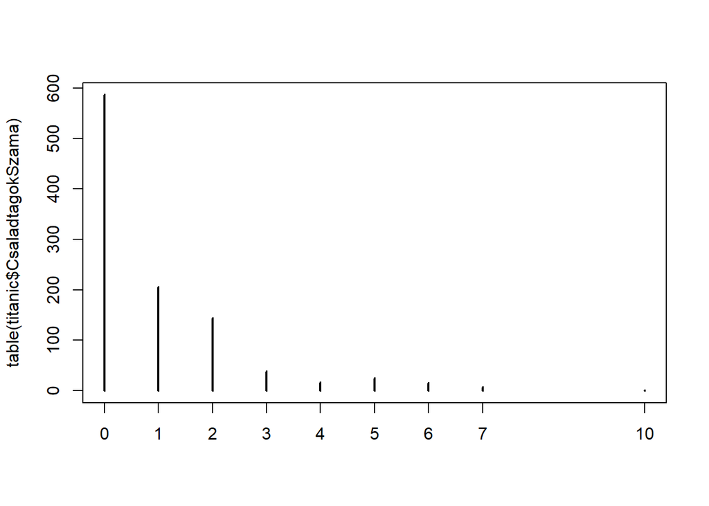

```r
plot(table(titanic$CsaladtagokSzama))
```

Látható is így, hogy a móduszunk a legkisebb érték az adatsorban, és lényegesen többször fordul elő, mint akár a második leggyakoribb elemből az 1-ből.  
Itt *nem* érdemes a `hist` függvényt alkalmazni az ábrázoláshoz, hiszen az automatikusan csoportokra (tól-ig határokra) akarja bontani az adatokat a gyakorisgok megadásához, de itt a családtagok számának kis értékkészlete miatt ennek nincs sok értelme.

Lássuk mi a helyzet az utasok **életkor**ának móduszával! Itt nem lesz ilyen egyszerű a módusz meghatározása, mert az életkornak sokkal nagyobb az értékkészlete, mint a saládtagok számának, így a `table` függvény eredménye is elég terebélyes:

```r
table(titanic$Kor)
```

```
##
## 0.1667 0.3333 0.4167 0.6667   0.75 0.8333 0.9167      1      2      3      4
##      1      1      1      1      3      3      2     10     12      7     10
##      5      6      7      8      9     10     11   11.5     12     13     14
##      5      6      4      6     10      4      4      1      3      5      8
##   14.5     15     16     17     18   18.5     19     20   20.5     21     22
##      2      6     19     20     39      3     29     23      1     41     43
##   22.5     23   23.5     24   24.5     25     26   26.5     27     28   28.5
##      1     26      1     47      1     34     30      1     30     32      3
##     29     30   30.5     31     32   32.5     33     34   34.5     35     36
##     30     40      2     23     24      4     21     16      2     23     31
##   36.5     37     38   38.5     39     40   40.5     41     42     43     44
##      2      9     13      1     20     18      3     11     18      9     10
##     45   45.5     46     47     48     49     50     51     52     53     54
##     21      2      6     14     14      9     15      8      6      4     10
##     55   55.5     56     57     58     59     60     61     62     63     64
##      8      1      4      5      6      3      7      5      4      4      5
##     65     66     67     70   70.5     71     74     76     80
##      3      1      1      2      1      2      1      1      1
```

Ebből a táblából aztán nehezen lesz meg a leggyakoribb kor szemmelveréssel. Inkább használjuk a `max` függvényt! Mentsük el a `table` függvény eredményét egy R objektumba

```r
gyak_kor <- table(titanic$Kor)
str(gyak_kor)
```

```
##  'table' int [1:97(1d)] 1 1 1 1 3 3 2 10 12 7 ...
##  - attr(*, "dimnames")=List of 1
##   ..$ : chr [1:97] "0.1667" "0.3333" "0.4167" "0.6667" ...
```

Aztán keressük meg azt az elemet az új, **gyak_kor** objektumban, ahol a gyakoriság értréke egyenlő a maximális gyakorisággal:

```r
gyak_kor[gyak_kor==max(gyak_kor)]
```

```
## 24
## 47
```

Így már látjuk, hogy a legtöbb utasunk, konkrétan 47 fő 24 éves. Nézzük meg az osztályközös gyakorisági táblában hol helyezkedne el ez az érték:

```r
library(RcmdrMisc)
binnedCounts(titanic$Kor)
```

```
## Binned distribution of titanic$Kor
##          Count Percent
## [0, 5]      56    5.37
## (5, 10]     30    2.88
## (10, 15]    29    2.78
## (15, 20]   133   12.75
## (20, 25]   195   18.70
## (25, 30]   166   15.92
## (30, 35]   115   11.03
## (35, 40]    94    9.01
## (40, 45]    72    6.90
## (45, 50]    60    5.75
## (50, 55]    36    3.45
## (55, 60]    26    2.49
## (60, 65]    21    2.01
## (65, 70]     4    0.38
## (70, 75]     4    0.38
## (75, 80]     2    0.19
## Total     1043   99.99
```

Azt láthatjuk, hogy a legtöbb utas életkora 20-25 év közötti, és a 24 év móduszunk is ebbe a kategóriába esik. Minden rendben. :)

A módusz egyébként az egyetlen helyzetmutató, amely **mind a 4 mérési skála esetén alkalmazható**! Hiszen a legtöbbször előforduló értéket még a *nominális* mérési skála esetén is meg lehet adni! Pl. meg tudjuk nézni a **BeszallasHelye** móduszát:

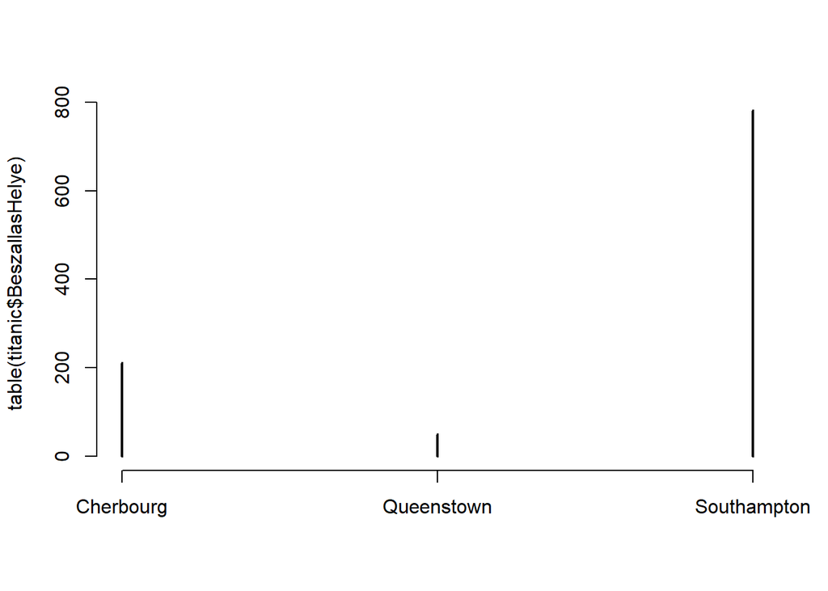

```r
plot(table(titanic$BeszallasHelye))
```

Könnyen leolvasható, hogy a leggyakoribb beszállási állomás *Southampton* volt.

Ezek után foglaljuk össze a **módusz tulajdonságait**:

- **Minden mérési skála esetén alkalmazható**: láthattuk, hogy még a *nominális*, **BeszallasHelye** változónak is meg tudtuk adni a móduszát
- **Nem mindig határozható meg egyértelműen**: simán előfordulhat, hogy kettő vagy még több leggyakoribb elem van!
- **Nem informatív nagy értékkészletű változók esetén**: Ezt a **Kor** és **CsaladtagokSzama** változók esete szépen szemlélteti. A kis értékkészletű **CsaladtagokSzama** változó esetén a 0-s módusz az adatsor több, mint felét kiteszi (*587/1043*), míg a sokféle lehetséges értékből álló **Kor** változó esetén a 24 éves módusz 5%-át sem teszi ki az elemeknek (*47/1043*). Tehát *kis értékkészlet esetén a módusz “jobban uralja” az adatsort*!
- **Nem érzékeny a kilógó értékekre**: Gondoljunk bele, ha pl. a **Kor** változó esetében egy 35-ös életkort adatrögzítési hiba miatt véletlen 3500-nak vennénk, az a 24 éves módusz értékén nem változtatna, ettől még ő maradna a leggyakoribb érték.

### 2.2. A medián

Középiskolás ismereteink alapján a mediánt valahogy úgy adtuk meg, hogy a *növekvő sorrendbe rendezett adatok esetén a középső elem*, és ha nincs középső elem (mert az adatok elemszáma páros), akkor a két középső elem átlaga.

Na ezt a definíciót úgy lehetne pontosítani, hogy azt mondjuk: **egy változó mediánja az az érték, aminél a változó értékeinek 50%-a kisebb, másik fele pedig nagyobb**.  
A definíció vizuális megjelenítése egy számegyenes segítségével az alábbi alakot öltheti, egy tetszőleges $Y$ változó $i$-edik értékét $Y_i$-vel jelölve:

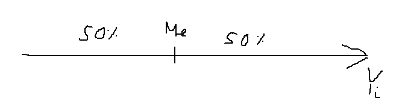

Lássuk is mennyi a **CsaladtagokSzama** változó mediánja! Szerencsére erre a mutatóra már van beépített függvénye az R-nek:

```r
median(titanic$CsaladtagokSzama)
```

```
## [1] 0
```

Az eredmény $0$. Tehát az utasok fele 0 vagy kevesebb, másik felük 0 vagy több családtaggal utazott együtt a hajón. Ez nem meglepő, hiszen a módusz kapcsán láttuk, hogy a leggyakoribb családtagszám, a 0 egyben a legkisebb érték is, és az adatok több, mint felét (*587/1043*) kiteszi. Ezek után már nyilvánvaló, hogy ez a $0$ érték lesz a medián is.

Lássuk mi a helyzet a **Kor** változó esetében.

```r
median(titanic$Kor)
```

```
## [1] 28
```

Ez alapján azt mondhatjuk, hogy a Titanic utasainak fele 28 éves vagy fiatalabb, másik felük meg 28 éves vagy idősebb volt. Ez reálisnak is hat: a Titanic 1912.ben utazott ki, akkor pedig a várható élettartam még lényegesen kisebb volt, így logikus, hogy az utasok felének a kora nem haladja meg a 28 évet.

Gondoljuk végig a **medián tulajdonságait**:

- **Mindig egyértelműen meghatározató**: A középső elemből nem lehet több, mint egy, ellenben a leggyakoribbal
- **Legalább ordinális mérési skálán alkalmazható**: A számításához csak sorba kell igazából rendezni a változó értékeit. Szóval egy sorbarendezhetőséget elég megkövetelni a változónktól a számításához. Így pl. a *kabinosztály* változóra is számítható és értelmezhető lenne.
- **Kis értékkészletű változók esetén nem informatív**: Ugyanakkor, azért nem számolnánk itt ki az **Osztaly** változóra, mert az értékkészlete nagyon kicsi, konkrétan 3 lehetséges étéke van (I., II. vagy III. osztályú utasunk kabinja). Kb. *triviális*, hogy az utasok kabinosztályának a fele II. osztályú vagy kisebb, másik felének meg II. osztályú vagy nagyobb. A kis értékkészlet miatt ebben a változóban sok más lehetősége nincs a mediánnak, mint középső elem.
- **Nem érzékeny a kilógó értékekre**: Itt is igaz, hogy pl. a **Kor** változó esetében egy 35-ös életkort adatrögzítési hiba miatt véletlen 3500-nak vennénk, az a 28 éves medián értékén nem változtatna, ettől még ő maradna a középső elem, alias a felezőpont.

A medián utolsó tulajdonságát teszteljük is le írjuk át a **Kor** változóban az első értéket 16-ról 16000-re, és nézzük meg más lesz-e a 28-as medián:

```r
titanic$Kor[1]
```

```
## [1] 16
```

```r
titanic$Kor[1] <- 16000

median(titanic$Kor)
```

```
## [1] 28
```

Hát tényleg nem nem! :) Na akkor írjuk is vissza a dolgokat:

```r
titanic$Kor[1] <- 16
```

### 2.3. Az átlag

Az átlag ugyebár nem más középiskolás tudásunk alapján, mint a **változó elemeinek összege osztva az adatok elemszámával**. Ez képletileg az alábbi módon néz ki, ha egy tetszőleges $Y$ változó $i$-edik értékét $Y_i$-vel jelöljük, az adatok elemszámát pedig $N$-nel:
$$\bar{Y}=\frac{Y_1+Y_2+...+Y_N}{N}=\frac{\sum_{i=1}^N{Y_i}}{N}$$

Az átlag számítására a `mean` névre hallgató beépített R függvény használható:

```r
mean(titanic$CsaladtagokSzama)
```

```
## [1] 0.9261745
```

```r
mean(titanic$Kor)
```

```
## [1] 29.8132
```

Tehát egy átalgos utas kb. $0.93$ családtagjával utazott együtt a hajón és $29.8$ éves.

Vesézzük ki az **átlag tulajdonságai**t is. Igazából csak kettőt kell észben tartani, de azokat nagyon:

- **Csak intervallum vagy arány mérési skála esetén alkalmazható**: Mivel az elemeket összeadjuk az átalgolás során, így az összeadás műveletnek értelmezhetőnek kell lennie a változón, amit átlagolunk. Ez pedig csak az intervallum és arány mérési szintű adatokon lehetséges, ahol két érték között a távolság egyértelműen megadható. Ebből pedig az fakad, hogy pl. *osztályzatokra* és *Likert-skálán* (1-7 mennyire ért egyet egy állítással) **tilos** átlagot vizsgálni, hiszen ezek ordinális mérési skálájú adatok! Itt legfeljebb csak móduszt és mediánt van értelme nézni!
- **Érzékeny a kilógó értékekre**: Ez is abból jön, hogy a számítás során minden elemet összeadunk. Ellenben a módusz és medián esetével, itt már *nagyon is számít* az átlag értékében, ha egy 35-ös életkort adatrögzítési hiba miatt véletlen 3500-nak vennénk.

A második tulajdonságot próbáljuk is ki a mediánnál alkalmazott példán! Írjuk át a **Kor** változóban az első értéket 16-ról 16000-re, és nézzük meg más lesz-e a 29.8 éves átlagéletkor:

```r
titanic$Kor[1]
```

```
## [1] 16
```

```r
titanic$Kor[1] <- 16000

mean(titanic$Kor)
```

```
## [1] 45.13822
```

Hujjaj! Rögtön 45.1 évre kúszott fel az átlagéletkor egy darab hibásan rögzített adat miatt! Ejjnye! Írjuk is vissza gyorsan azt a 16-ot:

```r
titanic$Kor[1] <- 16
mean(titanic$Kor)
```

```
## [1] 29.8132
```

Na, így már mindjárt szebb! :)

### 2.4. Átlag vs Medián

Láthatjuk tehát, hogy az átlag nagyon érzékeny a kilógó értékekre. Ebből is adódik, hogy pl. a **CsaladtagokSzama** változóban az átlag értéke eléggé különbözik a módusz és medián $0$-s értékétől:

```r
median(titanic$CsaladtagokSzama)
```

```
## [1] 0
```

```r
mean(titanic$CsaladtagokSzama)
```

```
## [1] 0.9261745
```

Az átlag lényegesen nagyobb a módusz-medián párosnál. Ez pedig kilógó értékre, ráadásul *felfelé* kilógó értékre (mivel az átlag felfelé tér el a másik két helyzetmutatóhoz képest) utal a változóban.  
Ha pedig megnézzük a változónk *eloszlását* a gyakoriságokból készített oszlopdiagramon, akkor fel is fedezzük, hogy a korábban is észrevett 1 szem 10-es az a felfelé kilógó érték:

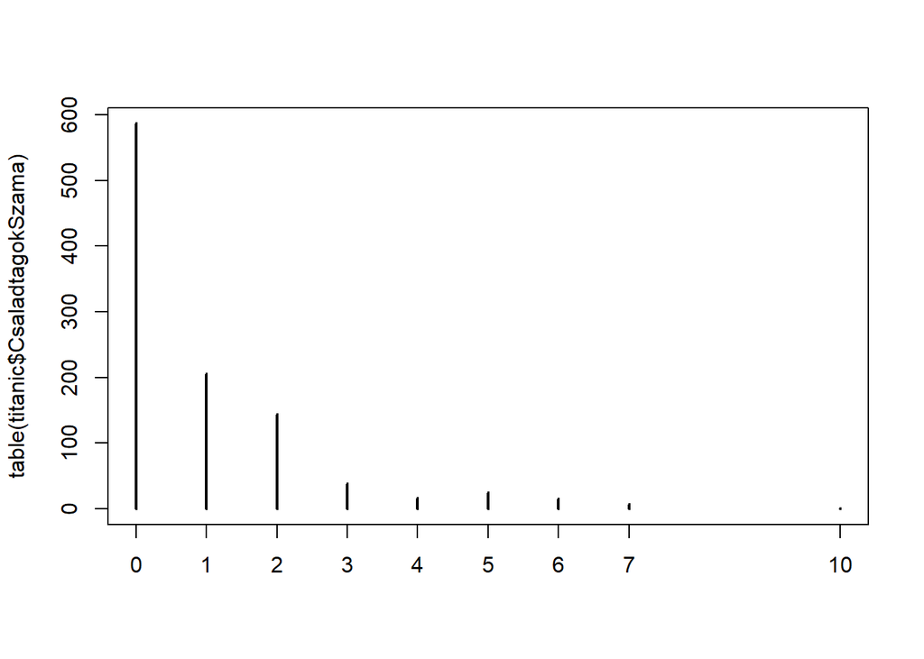

```r
plot(table(titanic$CsaladtagokSzama))
```

```r
median(titanic$Kor)
```

```
## [1] 28
```

```r
mean(titanic$Kor)
```

```
## [1] 29.8132
```

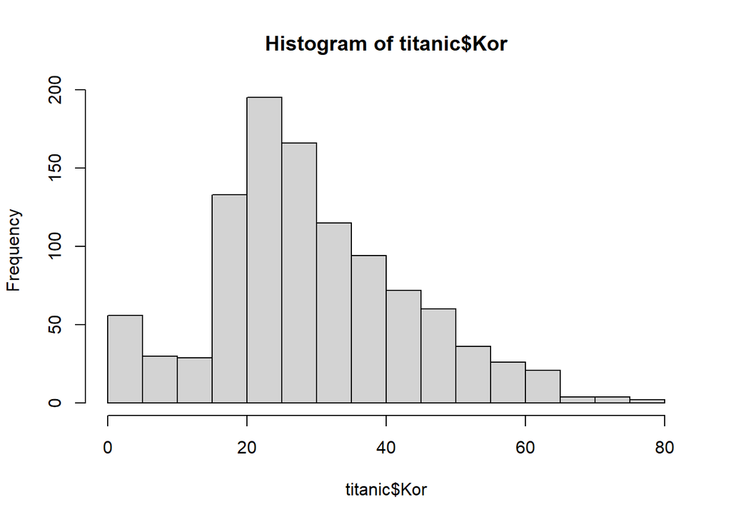

```r
hist(titanic$Kor)
```

Ha mindenki ennyire a változó értékkészletének közepén helyezkedik el, és semmilyen irányban nincsenek kilógó értékek, akkor a három helyzetmutatónk értéke kb. egybe fog esni. Ha le vagy fel **vannak kilógó értékek** a változó *eloszlásában*, akkor az **átlag a kilógó értékek irányába el fog térni a medián-módusz értékétől**! Erre a jelenségre majd visszatérünk még egy picit részletesebben, de most gondolkodjunk el még valamin.

Ha belegondolunk, akkor a valóságban a **jövedelem adatok eloszlása hasonló, mint a családtagok száma a hajón: sok kisebb érték van, de előfordul 1-2 kilógóan nagy érték**. Ugyebár egy társadalomnak van egy széles réteget jellemző jövedelmi szintje, de minden nemzetnek vannak milliárdos gázszerelői, akik kevesen vannak, de a jövedelmük lényegesen nagyobb, mint a társadalom széles rétegeire jellemző jövedelmi szint.  
Ebből pedig egyenesen következik, hogy a jövedelem helyzetmutatói közül az átlag lényegesen magasabb értéket fog mutatni, mint a medián! Tehát az **átlagjövedelem mindig magasabb, mint** az a jövedelem, aminél az emberek fele többet keres, azaz **a középső jövedelem**!

Az egyik extrém példa a jelenségre Az USA-ból jön: Washington állam Seattle megyéjében van egy Medina nevű kisváros. A városban 2003-ban 1204 db háztartás volt. Ám a jövedelemadó megfelelően alacsony kulcsa miatt ide voltak bejelentve a következő emberkék:

- Bill Gates: 46 milliárd dollár
- Jeff Bezos: 5 milliárd dollár
- Craig McCaw: 2 milliárd dollár

Ezek után a következőképpen néz ki kisvárosunkban az átlagos háztartás vagyona *minden háztartást figyelembe véve (piros)*, a *leggazdagabb Bill Gates nélkül (zöld)* és a *3 leggazdagabb háztartás nélkül (kék)*:

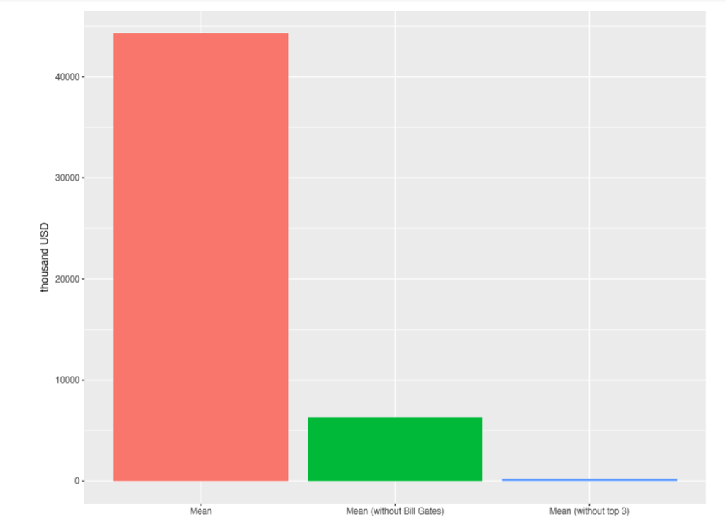

Szép kis különbségek, mi? :) Emiatt érdemesebb kilógó értékek esetén a **mediánnal mérni a változónk középértékét**, mint az átlaggal!

Csak hogy legyen magyar példánk is: 2019-ben a NAV jövedelemadó bevallásai alapján a magyar *pénzügyi szektorban* a medián jövedelem havi bruttó $403412$ Ft, míg az átlagjövedelem a zsíros bankigazgatói fizuk miatt $531390$ Ft-ra rúg!

Az átlag ilyen szintű érzékenységét a kilógó értékekre lehet kezelni úgynevezett **nyesett átlag** számolásával, ami az adatsor legnagyobb és legkisebb *x százalékát levágva* számol átlagot. Az R `mean` függvényében egy `trim` nevű paraméterrel lehet ezt szabályozni:

```r
# átlagos viteldíj
mean(titanic$Viteldij)
```

```
## [1] 36.60302
```

```r
# viteldíj nyesett átlag az alsó-felső 5% levágásával
mean(titanic$Viteldij, trim = 0.05)
```

```
## [1] 27.40542
```

```r
# medián viteldíj
median(titanic$Viteldij)
```

```
## [1] 15.75
```

A Titanic utasainak átlagos viteldíja kb $10$ fontot csökkent a felső+alsó 5% elhagyásával az átlagszámításból! De az utasok felének viteldíja még így is kisebb, mint 15.75 font!

Nem meglepő módon a viteldíjak *hisztogramját* vizsgálva találunk szép kis felfelé kilógó értékeket a *300+ fontos* viteldíjak formájában:

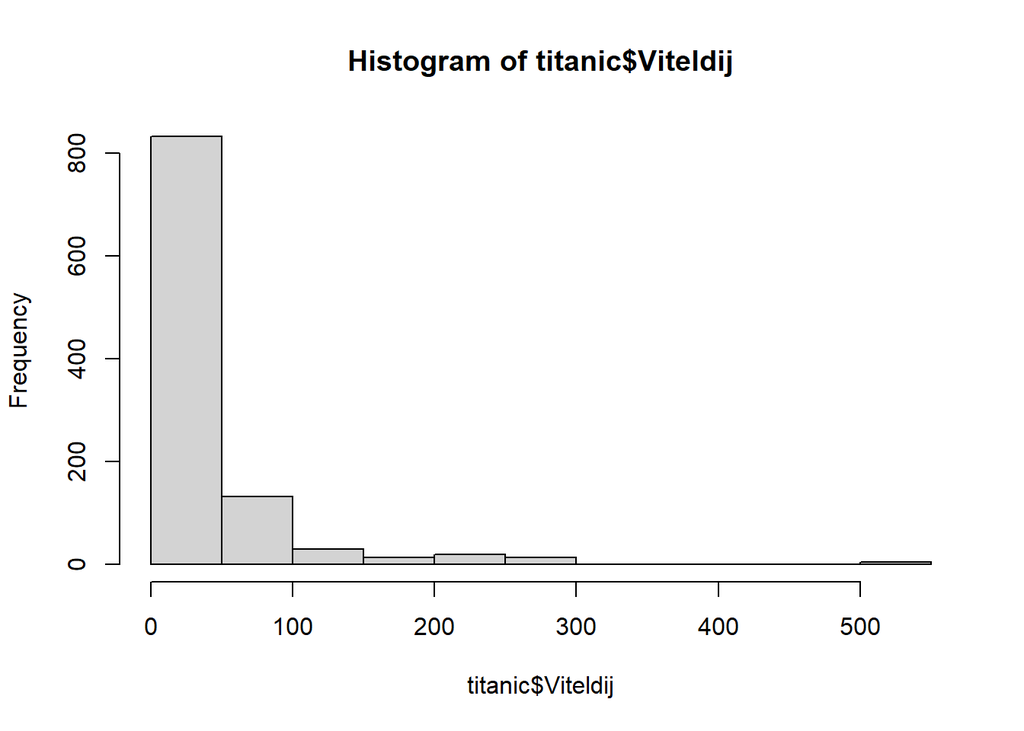

```r
hist(titanic$Viteldij)
```

## 3. A kvantilisek

A **medián definíciójának általánosításával** egy teljesen új leíró statisztikai mutatószám-csoporthoz, a **kvantilisek**hez jutunk.

A medián ($Me$) ugyebár az az érték a válozóban, aminél az adatok 50%-a kisebb, 50%-a nagyobb:

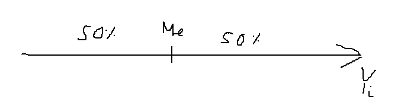

Ennek mintájára simán csinálhatok olyan mutatót is, aminél az adatok 25%-a kisebb, 75%-a nagyobb. VAGY fordítva: olyan mutatóm is lehet, aminél az adatok 75%-a kisebb, 25%-a nagyobb. Előbbi mutató az **alsó kvartilis**, azaz $Q_1$, míg utóbbi a **felső kvartilis**, $Q_3$:

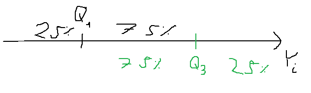

Ez a két kvartilis, a **mediánnal, mint második kvartilissel** ($Q_2=Me$) kiegészíülve **négy egyenlő gyakoriságú**, azaz 25%-25%-os részre bontják a vizsgált változó adatsorát, ezért ők a **negyedelőpontok, a kvartilisek**, és így 3-an vannak!

A kvartilisek mintájára sok más felosztású osztópontot is ki tudunk alakítani:

- ötödölő pontok: *kvinitilsek*, 4 db van belőlük
- tizedelő pontok: *decilisek*, 9 db van belőlük
- századoló pontok: *percentilisek*, 99 db van belőlük

Ezeket az **osztópontrendszerek**et hívjuk **együttesen kvantilis**eknek. Tehát figyelem: *minden kvartilis egy kvantilis, de nem minden kvantilis kvartilis*! :)

Nézzünk pár konkrét példát. A **második kvintilis**, azaz $K_2$ az az érték, aminél a változók $\frac{2}{5}=40\%$-a kisebb, és a maradék $60\%$-uk nagyobb:

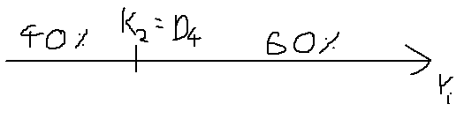

Ez egyben a **negyedik decilis**, azaz a $D_4$ érték is, hiszen úgy is mondhatom, hogy az adatok $\frac{4}{10}$-e ennél kisebb, $\frac{6}{10}$-e pedig ennél nagyobb.

A **30. percentilis**, azaz $P_{30}$ pedig az az érték, aminél a változónk értékeinek $\frac{30}{100}=30\%$-a kisebb, a maradék $70\%$-a pedig nagyobb. Természetesen, ez az érték egyben a **3. decilis**, azaz $D_3$ is:

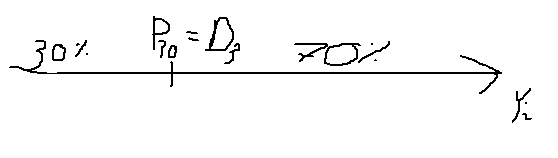

A **kvantilisek öröklik a medián összes tulajdonságát**. Azaz, legalább *ordinális* mérési skálájú változókra számíthatók, nem érzékenyek a kilógó értékekre és nem informatívak kis értékkészletű változók esetén.

Ezért most R-ben csak a **Kor** és **Viteldij** változókra vizsgálunk meg pár kvantilist, mint nagy értékkészletű és arány mérési skálájú változókra.

Az R-ben egy tetszőleges kvantilist a `quantile` függvénnyel lehet kiszámolni. A konkrét kvantilist az “*aláesési arányával*” lehet megadni a `probs` paraméterben:

```r
# Q1(Kor)
quantile(titanic$Kor, probs = 0.25)
```

```
## 25%
##  21
```

```r
# Q3(Viteldíj)
quantile(titanic$Viteldij, probs = 0.75)
```

```
##     75%
## 35.0771
```

Tehát a Titanic utasainak negyede *fiatalabb*, mint 21 év és szintén a Titanic utasainak negyede fizetett *legalább* 35 fontot az útért (azaz *legfeljebb* 3/4-ük fizetett ennyit).

Egyszerre több kvantilist ki tudunk számolni, ha a `probs` paramétert *vektorként* adjuk meg a `c()` függvénnyel:

```r
# Kvintilisek(Kor)
quantile(titanic$Kor, probs = c(0.2, 0.4, 0.6, 0.8))
```

```
## 20% 40% 60% 80%
##  19  25  31  42
```

```r
# Kvintilisek(Viteldíj)
quantile(titanic$Viteldij, probs = c(0.2, 0.4, 0.6, 0.8))
```

```
##      20%      40%      60%      80%
##  7.89580 13.00000 26.00000 51.08584
```

Tehát pl. a Titanic utasainak csak ötöde idősebb, mint 42 év (ez is a 100 évvel ezelőtti alacsony várható élettartamot tükrözi), és 40% fizetett kevesebbet az útért, mint 13 font és csak a legtehetősebb 20% fizetett többet a hajókázásért, mint 51 font.

## 4. A `summary` függvény

Egy `data frame` oszlopainak eddig tanult egyváltozós leíró statisztikáit R-ben nagyon könnyen le lehet kérni egyszerre a `summary` függvénnyel:

```r
summary(titanic)
```

```
##    Osztaly            Tulelt_e             Nev                Nem
##  Length:1043        Length:1043        Length:1043        Length:1043
##  Class :character   Class :character   Class :character   Class :character
##  Mode  :character   Mode  :character   Mode  :character   Mode  :character
##
##
##
##       Kor             Viteldij      BeszallasHelye     CsaladtagokSzama
##  Min.   : 0.1667   Min.   :  0.00   Length:1043        Min.   : 0.0000
##  1st Qu.:21.0000   1st Qu.:  8.05   Class :character   1st Qu.: 0.0000
##  Median :28.0000   Median : 15.75   Mode  :character   Median : 0.0000
##  Mean   :29.8132   Mean   : 36.60                      Mean   : 0.9262
##  3rd Qu.:39.0000   3rd Qu.: 35.08                      3rd Qu.: 1.0000
##  Max.   :80.0000   Max.   :512.33                      Max.   :10.0000
```

Az eredményből láthatjuk, hogy van itt mindenféle földi jó mind a numerikus változónkra: kvartilisek és átlag mellett minimum, maximum is megadásra kerül.